# Regression Models in R

Ken Wood

9/9/2020

### Executive Summary

Motor Trend, a magazine about the automobile industry, wants to look at a data set of a collection of cars to learn more about mileage. They are interested in exploring the relationship between a set of variables and miles per gallon (MPG) (outcome). Specifically, they are interested in answering the following two questions:

- “Is an automatic or manual transmission better for MPG?”
- “How do we quantify the MPG difference between automatic and manual transmissions?”

#### Load the ‘mtcars’ dataset and look at the first few rows…

```r
data(mtcars)
head(mtcars)
```

```
##                    mpg cyl disp  hp drat    wt  qsec vs am gear carb
## Mazda RX4         21.0   6  160 110 3.90 2.620 16.46  0  1    4    4
## Mazda RX4 Wag     21.0   6  160 110 3.90 2.875 17.02  0  1    4    4
## Datsun 710        22.8   4  108  93 3.85 2.320 18.61  1  1    4    1
## Hornet 4 Drive    21.4   6  258 110 3.08 3.215 19.44  1  0    3    1
## Hornet Sportabout 18.7   8  360 175 3.15 3.440 17.02  0  0    3    2
## Valiant           18.1   6  225 105 2.76 3.460 20.22  1  0    3    1
```

#### Variables in the ‘mtcars’ dataset…

- **mpg:** Miles/(US) gallon
- **cyl:** Number of cylinders
- **disp:** Displacement (cu.in.)
- **hp:** Gross horsepower
- **drat:** Rear axle ratio
- **wt:** Weight (1000 lbs)
- **qsec:** 1/4 mile time
- **vs:** Engine (0 = V-shaped, 1 = straight)
- **am:** Transmission (0 = automatic, 1 = manual)
- **gear:** Number of forward gears
- **carb:** Number of carburetors

#### Question 1: “Is an automatic or manual transmission better for MPG?”

First, let’s generate a box plot of MPG vs. transmission type…

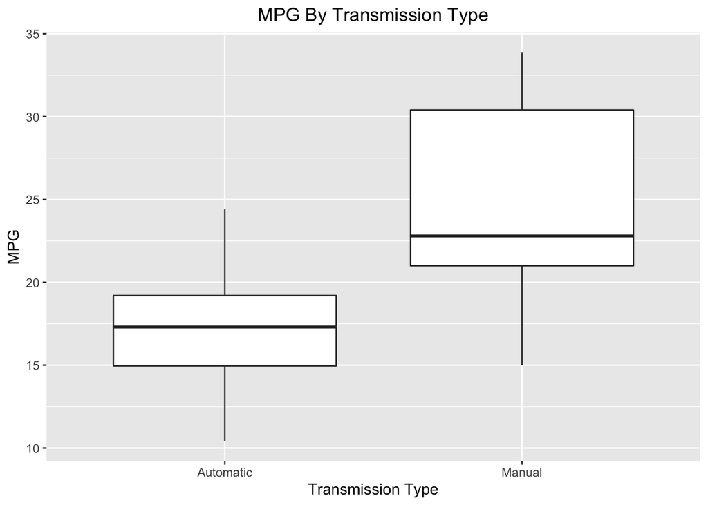

```r
library(ggplot2)
ggplot(mtcars, aes(x=factor(am), group=am, y=mpg)) + geom_boxplot() + scale_x_discrete(labels=c("0" = "Automatic", "1" = "Manual")) + xlab("Transmission Type") + ylab("MPG") + ggtitle("MPG By Transmission Type") + theme(plot.title = element_text(hjust = 0.5))
```

We can perform a t-test on the mean MPG numbers for cars with automatic vs. cars with manual transmissions. Our hypotheses will be as follows:

- $H_0$: $\mu_m$ - $\mu_a$ $= 0$
- $H_a$: $\mu_m$ - $\mu_a$ $\neq 0$

where $\mu_m$ and $\mu_a$ are the mean MPGs for manual and automatic transmissions, respectively.

We need to separate the MPG numbers according to automatic vs. manual transmission.

```r
manual <- mtcars[mtcars$am == 1,]     # get rows with manual transmission
automatic <- mtcars[mtcars$am == 0,]  # get rows with automatic transmission
manual <- manual[,"mpg"]
automatic <- automatic[,"mpg"]
row.names(manual) <- NULL             # remove row index
row.names(automatic) <- NULL
head(manual)
```

```
## [1] 21.0 21.0 22.8 32.4 30.4 33.9
```

```r
head(automatic)
```

```
## [1] 21.4 18.7 18.1 14.3 24.4 22.8
```

We can now perform a t-test between ‘manual’ and ‘automatic’.

```r
result <- t.test(manual,automatic)
result
```

```
##
##  Welch Two Sample t-test
##
## data:  manual and automatic
## t = 3.7671, df = 18.332, p-value = 0.001374
## alternative hypothesis: true difference in means is not equal to 0
## 95 percent confidence interval:
##   3.209684 11.280194
## sample estimates:
## mean of x mean of y
##  24.39231  17.14737
```

Our test result shows that we should reject $H_0$ with a p-value very close to $0$. The difference in the MPG means between manual and automatic transmissions is statistically significant at a 95% confidence level. Moreover, the mean MPG for manual transmissions $(x)$ is significantly higher than the mean MPG for automatic transmissions $(y)$.

#### Question 2: “How do we quantify the MPG difference between automatic and manual transmissions?”

We start by performing a linear regression with ‘mpg’ as the dependent variable and the rest of the columns in ‘mtcars’ as the independent variables.

```r
fit <- lm(mpg~.,data=mtcars)
summary(fit)
```

```
##
## Call:
## lm(formula = mpg ~ ., data = mtcars)
##
## Residuals:
##     Min      1Q  Median      3Q     Max
## -3.4506 -1.6044 -0.1196  1.2193  4.6271
##
## Coefficients:
##             Estimate Std. Error t value Pr(>|t|)
## (Intercept) 12.30337   18.71788   0.657   0.5181
## cyl         -0.11144    1.04502  -0.107   0.9161
## disp         0.01334    0.01786   0.747   0.4635
## hp          -0.02148    0.02177  -0.987   0.3350
## drat         0.78711    1.63537   0.481   0.6353
## wt          -3.71530    1.89441  -1.961   0.0633 .
## qsec         0.82104    0.73084   1.123   0.2739
## vs           0.31776    2.10451   0.151   0.8814
## am           2.52023    2.05665   1.225   0.2340
## gear         0.65541    1.49326   0.439   0.6652
## carb        -0.19942    0.82875  -0.241   0.8122
## ---
## Signif. codes:  0 '***' 0.001 '**' 0.01 '*' 0.05 '.' 0.1 ' ' 1
##
## Residual standard error: 2.65 on 21 degrees of freedom
## Multiple R-squared:  0.869,  Adjusted R-squared:  0.8066
## F-statistic: 13.93 on 10 and 21 DF,  p-value: 3.793e-07
```

We see that the p-values for all of the variable coefficients are > 0.05, therefore, we cannot draw any conclusions about the statistical significance of the coefficients. To find out which independent variables are statistically significant, we will make use of R’s ‘step’ function.

```r
# run 'step' analysis with direction = "backward"
step_analysis <- step(fit,trace=FALSE)  # suppress output
summary(step_analysis)
```

```
##
## Call:
## lm(formula = mpg ~ wt + qsec + am, data = mtcars)
##
## Residuals:
##     Min      1Q  Median      3Q     Max
## -3.4811 -1.5555 -0.7257  1.4110  4.6610
##
## Coefficients:
##             Estimate Std. Error t value Pr(>|t|)
## (Intercept)   9.6178     6.9596   1.382 0.177915
## wt           -3.9165     0.7112  -5.507 6.95e-06 ***
## qsec          1.2259     0.2887   4.247 0.000216 ***
## am            2.9358     1.4109   2.081 0.046716 *
## ---
## Signif. codes:  0 '***' 0.001 '**' 0.01 '*' 0.05 '.' 0.1 ' ' 1
##
## Residual standard error: 2.459 on 28 degrees of freedom
## Multiple R-squared:  0.8497, Adjusted R-squared:  0.8336
## F-statistic: 52.75 on 3 and 28 DF,  p-value: 1.21e-11
```

Our step analysis results indicate that the coefficients for ‘wt’, ‘qsec’, and ‘am’ are statistically significant (p=values < 0.05) and our linear model comprised of these variables has a $R^2$ $= 0.85$, which means the model can account for about 85% of the variance in ‘mpg’.

Let’s generate residual plots for the simplified linear model obtained by the ‘step’ analysis:

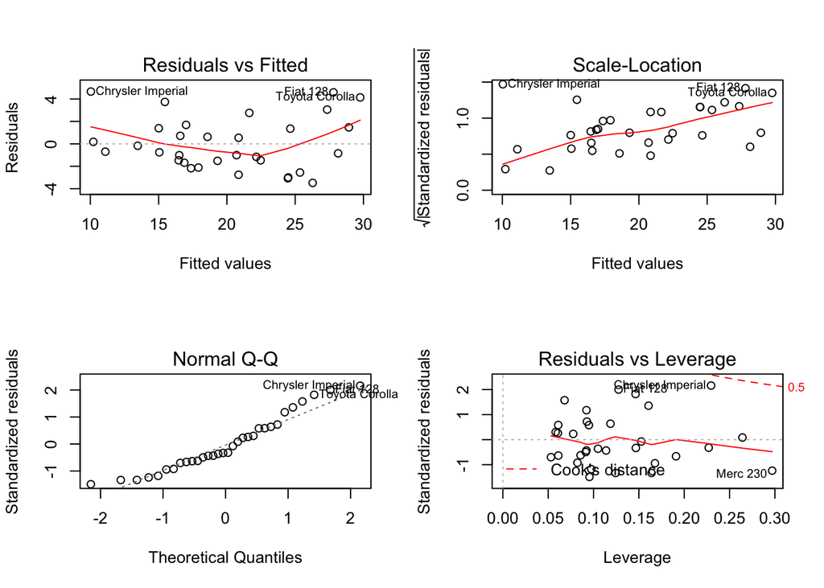

```r
layout(matrix(c(1,2,3,4),2,2))      # display the plot area
plot(step_analysis)
```

### Conclusions

- Using the final model output by the ‘step’ function, we see that the multiple $R^2$ value is sufficiently high at 0.85.
- We also see that ‘wt’ and ‘qsec’ are confounding variables in the relationship between ‘mpg’ and ’am’.
- The model predicts that cars with manual transmission will provide, on average, an additional 2.94 MPG compared to cars with automatic transmission.